# Hospital Readmissions Data Analysis and Recommendations for Reduction

### Background

In October 2012, the US government's Center for Medicare and Medicaid Services (CMS) began reducing Medicare payments for Inpatient Prospective Payment System hospitals with excess readmissions. Excess readmissions are measured by a ratio, by dividing a hospital’s number of “predicted” 30-day readmissions for heart attack, heart failure, and pneumonia by the number that would be “expected,” based on an average hospital with similar patients. A ratio greater than 1 indicates excess readmissions.

### Exercise Directions

In this exercise, you will:

- critique a preliminary analysis of readmissions data and recommendations (provided below) for reducing the readmissions rate
- construct a statistically sound analysis and make recommendations of your own

More instructions provided below. Include your work **in this notebook and submit to your Github account**.

### Resources

- Data source: https://data.medicare.gov/Hospital-Compare/Hospital-Readmission-Reduction/9n3s-kdb3
- More information: http://www.cms.gov/Medicare/medicare-fee-for-service-payment/acuteinpatientPPS/readmissions-reduction-program.html
- Markdown syntax: http://nestacms.com/docs/creating-content/markdown-cheat-sheet

```python
%matplotlib inline

import pandas as pd
import numpy as np
import matplotlib.pyplot as plt
import bokeh.plotting as bkp
from mpl_toolkits.axes_grid1 import make_axes_locatable
```

```python
# read in readmissions data provided
hospital_read_df = pd.read_csv('data/cms_hospital_readmissions.csv')
```

## Preliminary Analysis

```python
# deal with missing and inconvenient portions of data
clean_hospital_read_df = hospital_read_df[hospital_read_df['Number of Discharges'] != 'Not Available']
clean_hospital_read_df.loc[:, 'Number of Discharges'] = clean_hospital_read_df['Number of Discharges'].astype(int)
clean_hospital_read_df = clean_hospital_read_df.sort_values('Number of Discharges')
```

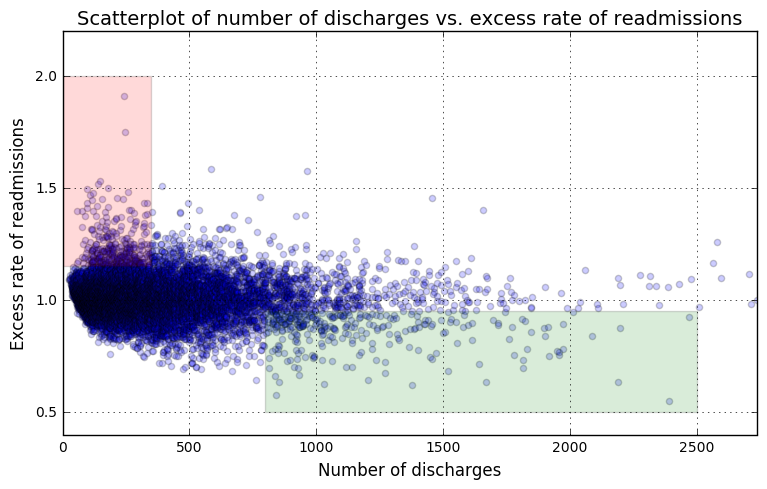

```python
# generate a scatterplot for number of discharges vs. excess rate of readmissions
# lists work better with matplotlib scatterplot function
x = [a for a in clean_hospital_read_df['Number of Discharges'][81:-3]]
y = list(clean_hospital_read_df['Excess Readmission Ratio'][81:-3])

fig, ax = plt.subplots(figsize=(8,5))
ax.scatter(x, y,alpha=0.2)

ax.fill_between([0,350], 1.15, 2, facecolor='red', alpha = .15, interpolate=True)
ax.fill_between([800,2500], .5, .95, facecolor='green', alpha = .15, interpolate=True)

ax.set_xlim([0, max(x)])
ax.set_xlabel('Number of discharges', fontsize=12)
ax.set_ylabel('Excess rate of readmissions', fontsize=12)
ax.set_title('Scatterplot of number of discharges vs. excess rate of readmissions', fontsize=14)

ax.grid(True)
fig.tight_layout()
```

## Preliminary Report

Read the following results/report. While you are reading it, think about if the conclusions are correct, incorrect, misleading or unfounded. Think about what you would change or what additional analyses you would perform.

**A. Initial observations based on the plot above**

- Overall, rate of readmissions is trending down with increasing number of discharges
- With lower number of discharges, there is a greater incidence of excess rate of readmissions (area shaded red)
- With higher number of discharges, there is a greater incidence of lower rates of readmissions (area shaded green)

**B. Statistics**

- In hospitals/facilities with number of discharges < 100, mean excess readmission rate is 1.023 and 63% have excess readmission rate greater than 1
- In hospitals/facilities with number of discharges > 1000, mean excess readmission rate is 0.978 and 44% have excess readmission rate greater than 1

**C. Conclusions**

- There is a significant correlation between hospital capacity (number of discharges) and readmission rates.
- Smaller hospitals/facilities may be lacking necessary resources to ensure quality care and prevent complications that lead to readmissions.

**D. Regulatory policy recommendations**

- Hospitals/facilties with small capacity (< 300) should be required to demonstrate upgraded resource allocation for quality care to continue operation.
- Directives and incentives should be provided for consolidation of hospitals and facilities to have a smaller number of them with higher capacity and number of discharges.

### Exercise

Include your work on the following **in this notebook and submit to your Github account**.

A. Do you agree with the above analysis and recommendations? Why or why not?

B. Provide support for your arguments and your own recommendations with a statistically sound analysis:

1. Setup an appropriate hypothesis test.
2. Compute and report the observed significance value (or p-value).
3. Report statistical significance for $\alpha$ = .01.
4. Discuss statistical significance and practical significance. Do they differ here? How does this change your recommendation to the client?
5. Look at the scatterplot above.
   - What are the advantages and disadvantages of using this plot to convey information?
   - Construct another plot that conveys the same information in a more direct manner.

You can compose in notebook cells using Markdown:

- In the control panel at the top, choose Cell > Cell Type > Markdown
- Markdown syntax: http://nestacms.com/docs/creating-content/markdown-cheat-sheet

### Answer:

In hospitals/facilities with number of discharges < 100, 63% have excess readmission rate greater than 1 and  
in hospitals/facilities with number of discharges > 1000, 44% have excess readmission rate greater than 1. From this data it seems that hospitals/facilities with number of discharges < 100 seems to have more excess readmission rate. However, the difference in mean excess readmission rate for hospitals/facilities with number of discharges < 100 and hospitals/facilities with number of discharges > 1000 is only 0.045 (1.023 - 0.978). Also what about the hospitals/facilities with number of discharges >= 100 and <= 1000?

*H0* excess readmission rate for hospitals/facilities with number of discharges < 100 is the same as excess readmission rate for hospitals/facilities with number of discharges > 1000.

*H1* excess readmission rate for hospitals/facilities with number of discharges < 100 is more than excess readmission rate for hospitals/facilities with number of discharges > 1000.

#### Clean-up the data:

```python
from scipy import stats
import seaborn as sns

# pick the right set of data
df = clean_hospital_read_df.rename(columns={'Number of Discharges': 'num_discharges',
                                       'Excess Readmission Ratio': 'excess_readm_ratio'})

# for hosiptals / facilities < 100 discharges
df_1_99 = df[(df.num_discharges > 0) & (df.num_discharges < 100)]
df_1_99 = df_1_99[['num_discharges', 'excess_readm_ratio']]

# for hosiptals / facilities >= 100 discharges and < 1000 discharges
df_100_1000 = df[(df.num_discharges > 99) & (df.num_discharges <= 1000)]
df_100_1000 = df_100_1000[['num_discharges', 'excess_readm_ratio']]

df_1000 = df[(df.num_discharges > 1000)]
df_1000 = df_1000[['num_discharges', 'excess_readm_ratio']]
```

#### Approach - 1: T-test

Compare the T-test for excess readmission rate for hospitals/facilities with number of discharges < 100, 100 <= number of discharges <= 1000 and number of discharges > 1000.

Particularly compare excess readmission rate for hospitals/facilities with number of discharges < 100 and number of discharges > 1000. *H0* is rejected if p_value is less than 0.01 (alpha = 0.01).

```python
stats.ttest_ind(df_1_99.excess_readm_ratio, df_100_1000.excess_readm_ratio, equal_var=False)
```

```
Ttest_indResult(statistic=8.0753888432731511, pvalue=1.1429796155993333e-15)
```

```python
stats.ttest_ind(df_100_1000.excess_readm_ratio, df_1000.excess_readm_ratio, equal_var=False)
```

```
Ttest_indResult(statistic=5.0770320347675391, pvalue=5.460602921761529e-07)
```

```python
stats.ttest_ind(df_1_99.excess_readm_ratio, df_1000.excess_readm_ratio, equal_var=False)
```

```
Ttest_indResult(statistic=7.6017424185004856, pvalue=1.2752435451140344e-13)
```

#### Analysis

Since p_value is less than 0.01, *H0 is rejected*.

```python
stats_d = []
stats_d.append(stats.describe(df_1_99.excess_readm_ratio))
stats_d.append(stats.describe(df_100_1000.excess_readm_ratio))
stats_d.append(stats.describe(df_1000.excess_readm_ratio))
```

```python
idx_1_99 = 0
idx_100 = 1
idx_1000 = 2
idx_n = 0
idx_m = 2
idx_v = 3
```

```python
x_val = []
x_val.append(len(df_1_99[df_1_99.excess_readm_ratio > 1.0]))
x_val.append(len(df_100_1000[df_100_1000.excess_readm_ratio > 1.0]))
x_val.append(len(df_1000[df_1000.excess_readm_ratio > 1.0]))

p_val = []
p_val.append(x_val[idx_1_99] / stats_d[idx_1_99][idx_n])
p_val.append(x_val[idx_100] / stats_d[idx_100][idx_n])
p_val.append(x_val[idx_1000] / stats_d[idx_1000][idx_n])
```

```python
p_combined = (x_val[idx_1_99] + x_val[idx_1000]) / (stats_d[idx_1_99][idx_n] + stats_d[idx_1000][idx_n])
```

```python
p_sd = np.sqrt((p_combined) * (1 - p_combined))
n_sqrt = np.sqrt((1/stats_d[idx_1_99][idx_n]) + (1/stats_d[idx_1000][idx_n]))
z_score = (p_val[idx_1_99] - p_val[idx_1000]) / (p_sd * n_sqrt)
```

```python
p_values = stats.norm.sf(abs(z_score)) #one-sided
p_values
```

```
2.2062248455429338e-12
```

```python
p_values = stats.norm.sf(abs(z_score))*2 #twosided
p_values
```

```
4.4124496910858676e-12
```

#### Analysis

Since p_value is less than 0.01, *H0* is rejected.

From T-test and Z-test methods, it can be observed that in hospitals/facilities with number of discharges < 100, excess readmission rate is higher.

#### Plot

The scattered plot shows the distribution of all the data set well and it was easy to identify green and red regions. However, it does not show the distribution based on group and one cannot determine how one distribution relates to another.

The following distribution plot shows the distribution of excess readmission rate as per the various groups of hospitals/facilities with number of discharges. One can easily relates to distribution and mean of the sample looking at this plot.

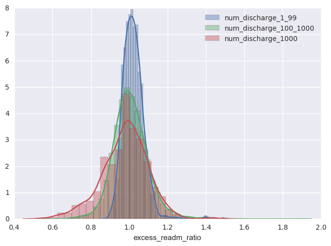

```python
sns.distplot(df_1_99.excess_readm_ratio, label="num_discharge_1_99")
sns.distplot(df_100_1000.excess_readm_ratio, label="num_discharge_100_1000")
sns.distplot(df_1000.excess_readm_ratio, label="num_discharge_1000")
plt.legend()
```